# Network Analysis

Fabio Zuliani

# Introduzione

Questo progetto ha come scopo l’analisi esplorativa della rete [Bitcoin OTC weighted signed network](https://snap.stanford.edu/data/soc-sign-bitcoin-otc.html). Questo grafo rappresenta le relazioni di fiducia e diffidenza tra utenti della piattaforma di trading OTC. Gli utenti valutano altri membri, con cui hanno effettuato una transazione, tramite una scala di valutazione a valori discreti da -10 a +10.

L’obiettivo principale di questa analisi è rispondere ad una serie di domande di ricerca, le quali successivamente verranno esposte e spiegate.

All’interno di questo progetto verranno studiate la struttura, la dinamica e le proprietà della rete, proponendo analisi a livello locale e globale.

## Bitcoin OTC

Bitcoin OTC (Over-the-Counter) è una piattaforma di scambio peer-to-peer che facilita transazioni dirette tra acquirenti e venditori. A differenza dei CEX, i quali agiscono come intermediari e mantengono registri completi degli utenti, le piattaforme OTC mirano ad un approccio più decentralizzato.

In un ambiente come la blockchain, dove la decentralizzazione è una proprietà fondamentale, i concetti di **fiducia** e **reputazione** sono **fondamentali**, per garantire la sicurezza e la buona riuscita delle transazioni. Ecco perchè Bitcoin OTC ha sviluppato una metodologia di rating in cui gli utenti possono valutare altri membri dopo aver interagito tra di loro.

L’analisi di questa rete ci permette di esplorare come la reputazione viene costruita e mantenuta in questo particolare contesto, possiamo verificare inoltre le proprietà studiate durante il corso riguardo le reti con segno, scoprendo le complessità di questo affascinante mondo.

La rete presa in considerazione in questo studio rappresenta esplicitamente le relazioni di fiducia e diffidenza tra gli utenti di Bitcoin OTC. L’analisi di tale rete ci permette di esplorare come la reputazione viene costruita e mantenuta in un contesto decentralizzato, e quali strutture sociali emergono da queste interazioni.

## Domande di ricerca

Dopo questa breve introduzione al dominio di provenienza della rete in questa sezione della relazione verranno presentate le domande di ricerca, lo scopo di questa analisi, infatti, è cercare le risposte ad una serie di quesiti che sono stati posti, attraverso operazioni, manipolazioni e proprietà della nostra rete.

I quesiti posti sono i seguenti:

1. **Chi sono gli utenti più influenti e affidabili nella rete? Inoltre, qual è la distribuzione della reputazione?**
2. **Questa rete con segno rispetta le proprietà di bilanciamento?**
3. **La topologia di questa rete rispetta la struttura di modelli teorici? La sua topologia ha qualche risvolto dal punto di vista della resilienza?**

# Analisi della rete

Terminata l’introduzione e la presentazione delle domande di ricerca, in questo capitolo verrà esposta la ricerca vera e propria, inizialmente verrà presentato il dataset, verranno esposte le sue caratteristiche principali, una volta terminata questa prima esplorazione verrà costruito il grafo che rappresenta la rete.

```r
library(tidyverse)
library(ggplot2)
library(igraph)
library(tidygraph)
library(ggraph)
library(signnet)

rete <- read.csv("dataset_completo.csv")

rete <- rete %>%
  rename(
    source = SOURCE,
    target = TARGET,
    weight = RATING
  )

# Formattazione data,ora riconoscibile da R
rete$timestamp <- paste(rete$DATE, rete$TIME)
rete$timestamp_datetime <- as.POSIXct(rete$timestamp, format = "%Y-%m-%d %H:%M:%S", tz = "GMT")

rete <- rete %>%
  select(
    source,
    target,
    weight,
    timestamp_datetime
  )

head(rete)
summary(rete$weight)
```

[output not shown]

Una volta caricato il dataset, è stata eseguita una breve attività di pre-processing dei dati. Durante la quale sono stati modificati e standardizzati i nomi delle colonne, sono state unite le colonne DATE, TIME e sono state formattate correttamente.

Il dataframe finale, con il quale verrà costruito il grafo si chiama dunque ‘rete’, è composto da 4 colonne:

1. **source**
2. **target**
3. **weight**
4. **timestamp_datetime**

Terminato il processo di pulizia e costruzione del dataset. La rete può dunque essere costruita.

# Analisi Preliminari

## Creazione della rete

Questa sezione è dedicata all’analisi delle proprietà fondamentali della rete, partendo dalla sua creazione. Queste prime analisi forniranno una prima idea grezza della scala e della connettività della rete.

Verranno calcolate le metriche fondamentali come il numero di nodi (gli utenti), il numero di archi (le transazioni) e la connettività per avere una prima panoramica della struttura.

```r
# Creazione grafo. La rete è diretta e pesata
g <- graph_from_data_frame(rete, directed = TRUE)

# Assegnazione pesi
E(g)$weight <- rete$weight

# Introduzione data, ora
E(g)$timestamp_datetime <- rete$timestamp_datetime

print(g)
```

```
## IGRAPH a7ecd7e DNW- 5881 35592 --
## + attr: name (v/c), weight (e/n), timestamp_datetime (e/n)
## + edges from a7ecd7e (vertex names):
##  [1] 1->10   1->101  1->1010 1->104  1->1053 1->109  1->110  1->111  1->1134
## [10] 1->114  1->115  1->119  1->120  1->1201 1->1217 1->1245 1->125  1->1281
## [19] 1->13   1->1316 1->1317 1->1318 1->132  1->134  1->135  1->1352 1->1353
## [28] 1->1363 1->1366 1->1369 1->138  1->1383 1->1386 1->139  1->1396 1->141
## [37] 1->143  1->144  1->1447 1->145  1->1487 1->15   1->1508 1->1541 1->1555
## [46] 1->1557 1->1565 1->1566 1->1585 1->159  1->1615 1->1620 1->165  1->1656
## [55] 1->1693 1->17   1->1701 1->171  1->1714 1->1727 1->1749 1->1753 1->1771
## [64] 1->178  1->180  1->1802 1->1810 1->1815 1->1860 1->1899 1->19   1->192
## + ... omitted several edges
```

```r
# Densità del grafo
density_g <- edge_density(g)
cat(paste("La densità del grafo è: ", density_g))
```

```
## La densità del grafo è:  0.00102925713730485
```

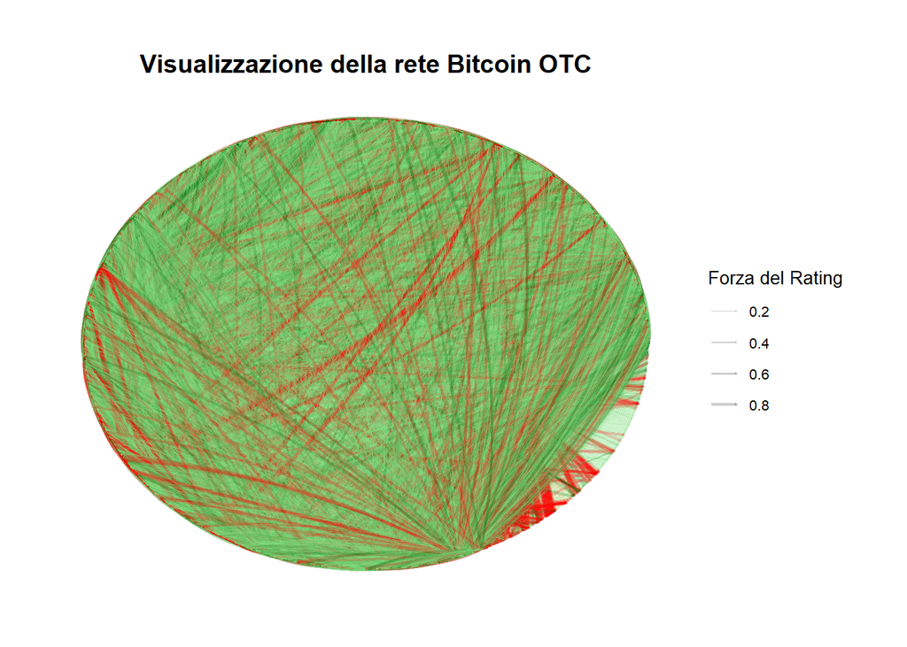

```r
g_plot <- g

# Colore degli archi: gradiente per la forza del peso.
E(g_plot)$weight_rescaled <- E(g_plot)$weight
E(g_plot)$edge_width <- abs(E(g_plot)$weight) / 10 * 0.8 # Spessore ridotto per la densità

# Impostiamo una dimensione minima per le frecce, ridotta per la densità.
E(g_plot)$arrow_size <- 0.1 + abs(E(g_plot)$weight) / 10 * 0.1

ggraph(g_plot, layout = 'circle') +
  # Disegna solo gli archi.
  geom_edge_fan(aes(color = weight_rescaled, width = edge_width),
                arrow = arrow(length = unit(E(g_plot)$arrow_size, 'mm'), type = "closed"),
                end_cap = circle(0.2, 'mm'),
                start_cap = circle(0.2, 'mm'),
                alpha = 0.2) +
  scale_edge_color_gradient2(low = "red", mid = "lightgreen", high = "darkgreen", midpoint = 0,
                             name = "Rating (Fiducia/Diffidenza)",
                             breaks = seq(-10, 10, by = 2),
                             labels = seq(-10, 10, by = 2)) +
  scale_edge_width(range = c(0.05, 0.8), name = "Forza del Rating") + # Range di spessore ridotto
  labs(title = "Visualizzazione della rete Bitcoin OTC") +
  theme_graph() +
  theme(plot.title = element_text(hjust = 0.5, face = "bold", size = 14),
        plot.subtitle = element_text(hjust = 0.5, size = 10),
        legend.position = "right",
        legend.title = element_text(size = 10),
        legend.text = element_text(size = 8),
        panel.background = element_rect(fill = "white", colour = NA)) +
  guides(edge_color = guide_colorbar(barwidth = 0.8, barheight = 10))
```

Dalla visualizzazione della rete si può dedurre che nel complesso la tendenza generale è la fiducia, in quanto il colore predominante è il verde. Grazie alla trasparenza degli archi, nonostante il numero elevato di archi, si capisce che la distribuzione della fiducia è eterogenea.

Nonostante il verde predominante sono comunque presenti archi rossi, questo significa che all’interno della rete sono presenti nodi “truffatori”, sono distribuiti in aree differenti del cerchio. Ciò conferma che il sistema di rating è attivamente utilizzato anche per segnalare esperienze negative, il che è cruciale per la sua efficacia come meccanismo di protezione dalle frodi. La densità degli archi rossi in alcune aree potrebbe indicare cluster di utenti che hanno accumulato o espresso molta diffidenza.

Nella prossima sezione verranno eseguite delle analisi sulla rete a livello locale. L’obiettivo è quello di studiare le misure di centralità, inoltre, seguendo i quesiti di ricerca, cercheremo di rispondere ad alcune domande che ci siamo posti, come per esempio verificare se questa rete rispetta la teoria del bilanciamento.

# Analisi Locale

In questa sezione ci concentreremo nello studio delle proprietà locali della nostra rete. Nello specifico nella prima parte del capitolo andremo ad analizzare il grado dei nodi della rete, in modo tale da poter rispondere al primo quesito di ricerca.

Prima di iniziare l’analisi definiamo un utente (nodo), influente come un nodo che ha un grado in entrata (in-degree) alto. Estendendo il concetto un nodo affidabile, è un nodo che riceve molti voti positivi.

## Distribuzione della fiducia

```r
# Normalizza i pesi (da -10/+10 a -1/+1)
E(g)$weight <- E(g)$weight / 10
E(g)$sign <- ifelse(E(g)$weight > 0, 1, -1)

# Crea sottografi per archi positivi e negativi
g_pos <- subgraph.edges(g, E(g)[E(g)$weight > 0], delete.vertices = FALSE)
g_neg <- subgraph.edges(g, E(g)[E(g)$weight < 0], delete.vertices = FALSE)

# Calcola i gradi in-degree per positivi e negativi
V(g)$pos_in_degree <- degree(g_pos, mode = "in")
V(g)$neg_in_degree <- degree(g_neg, mode = "in")

# Calcola il grado netto (differenza tra positivi e negativi)
V(g)$net <- V(g)$pos_in_degree - V(g)$neg_in_degree

summary(V(g)$net)
```

```
##    Min. 1st Qu.  Median    Mean 3rd Qu.    Max.
##  -69.00    1.00    1.00    4.84    4.00  535.00
```

```r
# Out-degree
V(g)$pos_out_degree <- degree(g_pos, mode = "out")
V(g)$neg_out_degree <- degree(g_neg, mode = "out")

# Distribuzione della positività nella rete
pos_ratio <- sum(V(g)$pos_in_degree) / (sum(V(g)$pos_in_degree) + sum(V(g)$neg_in_degree))
cat("Percentuale di trust positivo:", round(pos_ratio * 100, 2), "%\n")
```

```
## Percentuale di trust positivo: 89.99 %
```

```r
# Nodi più fidati (highest net)
top_trusted <- data.frame(
  node_id = V(g)$name,
  pos_in = V(g)$pos_in_degree,
  neg_in = V(g)$neg_in_degree,
  net = V(g)$net
) %>% arrange(desc(net))

cat("\nTop 10 nodi più fidati:\n")
```

```
##
## Top 10 nodi più fidati:
```

```r
print(head(top_trusted, 10))
```

```
##    node_id pos_in neg_in net
## 1       35    535      0 535
## 2     2642    411      1 410
## 3     1810    270     41 229
## 4        1    226      0 226
## 5        7    216      0 216
## 6     4197    203      0 203
## 7     4172    211     11 200
## 8       13    190      1 189
## 9     2028    234     45 189
## 10     905    226     38 188
```

```r
# Nodi più controversi (alto pos E alto neg)
controversial <- top_trusted %>%
  filter(pos_in > 10 & neg_in > 5) %>%
  mutate(controversy = neg_in / pos_in) %>%
  arrange(desc(controversy))

cat("\nNodi più controversi:\n")
```

```
##
## Nodi più controversi:
```

```r
print(head(controversial, 10))
```

```
##    node_id pos_in neg_in net controversy
## 1     2017     12     33 -21   2.7500000
## 2     4683     16     17  -1   1.0625000
## 3     4707     17     16   1   0.9411765
## 4     4733     15     14   1   0.9333333
## 5     5635     11     10   1   0.9090909
## 6     1383     51     45   6   0.8823529
## 7        3     12      9   3   0.7500000
## 8     2661     11      7   4   0.6363636
## 9       62     32     20  12   0.6250000
## 10    1543     33     18  15   0.5454545
```

```r
# Nodi con bilancio negativo
distrusted <- top_trusted %>%
  filter(net < 0) %>%
  arrange(net)

cat("\nNodi con bilancio negativo:\n")
```

```
##
## Nodi con bilancio negativo:
```

```r
print(head(distrusted, 10))
```

```
##    node_id pos_in neg_in net
## 1     3744      6     75 -69
## 2     2498      9     36 -27
## 3     4531      1     24 -23
## 4     2017     12     33 -21
## 5     4744      1     18 -17
## 6     4672      1     17 -16
## 7     3760      1     16 -15
## 8     4654      5     20 -15
## 9     4661      3     18 -15
## 10    4666      3     18 -15
```

```r
cat("Totale nodi con net < 0:", nrow(distrusted), "\n")
```

```
## Totale nodi con net < 0: 553
```

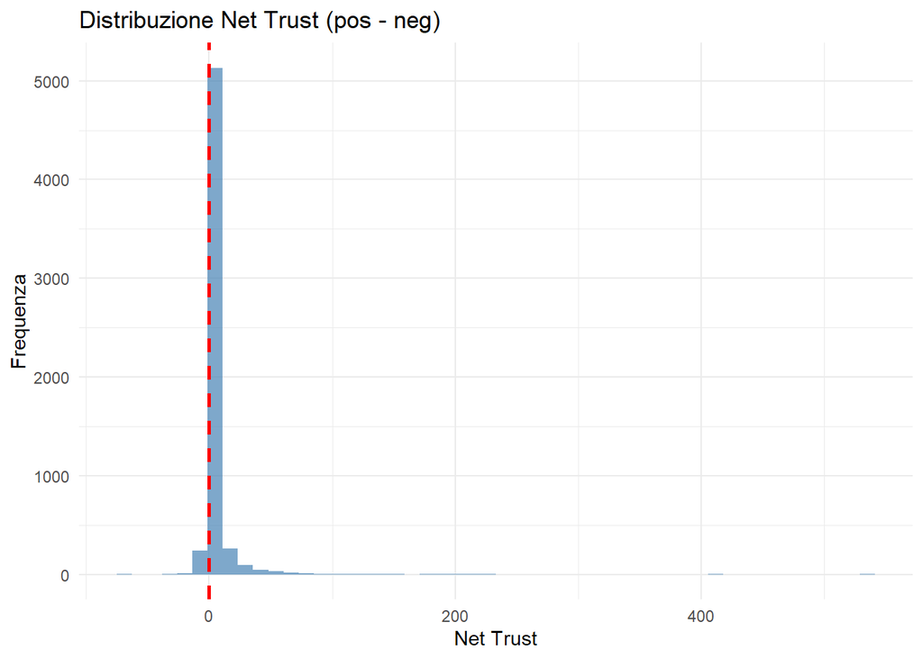

```r
# Distribuzione del net degree
ggplot(top_trusted, aes(x = net)) +
  geom_histogram(bins = 50, fill = "steelblue", alpha = 0.7) +
  geom_vline(xintercept = 0, color = "red", linetype = "dashed", size = 1) +
  theme_minimal() +
  labs(title = "Distribuzione Net Trust (pos - neg)",
       x = "Net Trust", y = "Frequenza")
```

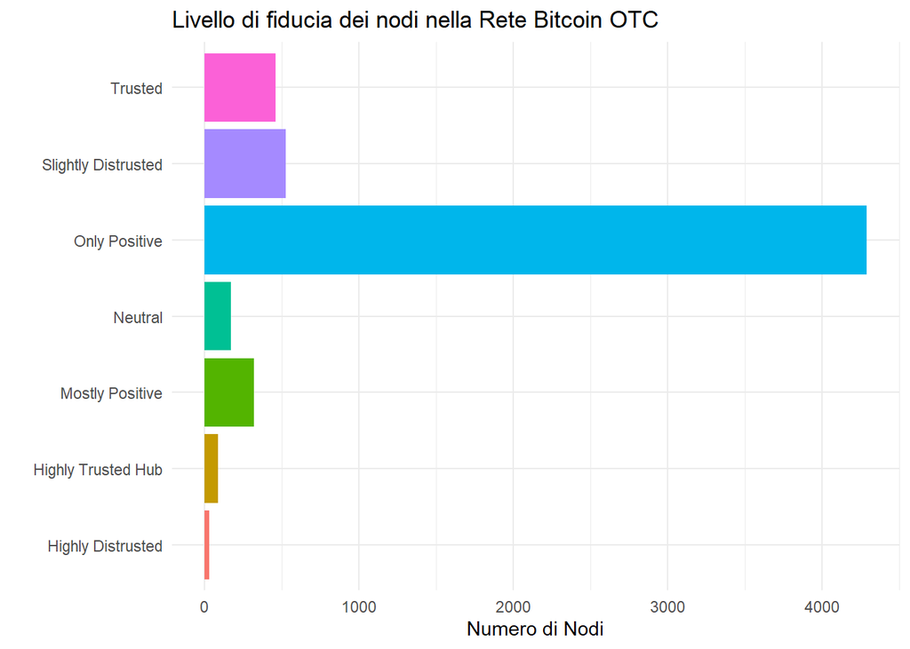

```r
top_trusted <- top_trusted %>%
  mutate(
    category = case_when(
      net > 50 ~ "Highly Trusted Hub",
      net > 10 ~ "Trusted",
      net > 0 & neg_in == 0 ~ "Only Positive",
      net > 0 & neg_in > 0 ~ "Mostly Positive",
      net == 0 ~ "Neutral",
      net < 0 & net > -10 ~ "Slightly Distrusted",
      TRUE ~ "Highly Distrusted"
    )
  )

ggplot(top_trusted, aes(x = category, fill = category)) +
  geom_bar() +
  coord_flip() +
  theme_minimal() +
  labs(title = "Livello di fiducia dei nodi nella Rete Bitcoin OTC",
       x = "", y = "Numero di Nodi") +
  theme(legend.position = "none")
```

Questa prima parte dell’analisi locale ci fornisce molteplici informazioni. Come primo elemento possiamo affermare che, come la rappresentazione grafica iniziale della rete ci aveva suggerito, la maggior parte delle transazioni ha avuto una recensione positiva. Infatti l’indice di $positive-trust$ è pari al $89.9\%$, proseguendo sono stati calcolati il grado in entrata (recensioni ricevute) e il grado in uscita (recensioni fornite), di ogni nodo. Essendo la rete pesata è stata aggiunta come informazione anche il voto della recensione.

Lo studio di questi due parametri ha prodotto delle informazioni interessanti, riassunte mediante i due grafici. All’interno dell’analisi, per ogni nodo è stato calcolato l’indice di fiducia netto ($pos - neg$), permettendo dunque di individuare i nodi a cui è stata riservata più fiducia e dall’altra parte identificare i nodi “truffatori”. Sono stati individuati anche i nodi definiti controversi, ossia dei nodi che hanno ricevuto sia valutazioni molto alte sia molto basse.

I due grafici finali riassumono queste informazioni, il primo grafico evidenzia come la maggior parte dei nodi (più di $4000$) ha un $positive-index$ maggiore di $0$ con una media che si attesta attorno al 5. Si nota dal grafico però che sono presenti anche due code sia a destra sia a sinistra, la prima più consistente, indicando dunque che sono presenti sia nodi con un valore di fiducia molto alto sia il contrario.

Il secondo grafico invece esplicita maggiormente la suddivisione in categorie basate sulla fiducia dei nodi. Sono state stabilite 7 fasce basate sull’indice netto, ancora una volta la fascia predominante è quella evidenziata dal primo grafico, inoltre analizzando la struttura delle fasce, la maggior parte dei nodi ha un indice negativo nullo.

## Analisi della centralità

Nella seconda parte analizzeremo più nel profondo i concetto di centralità della rete, in secondo luogo verrà studiata la domanda numero $2$, analizzando le triadi presenti nella rete, cercando di capire se la rete rispetta la teoria del bilanciamento o no.

```r
# Centrality (Katz)
A = as_adjacency_matrix(g, sparse=TRUE, attr="weight")
eig = eigen(A)$values
r = max(abs(eig))
alpha = 0.85 / r
k =  alpha_centrality(g, alpha = alpha)
V(g)$Katz = k

centrali_k <- data.frame(
  node_id = V(g)$name,
  central_index = V(g)$Katz
) %>% arrange(desc(central_index))

print(head(centrali_k))
```

```
##   node_id central_index
## 1    1810      32.99542
## 2    3897      24.40015
## 3       1      23.15721
## 4    2642      21.93188
## 5    4172      21.19358
## 6    4291      16.49929
```

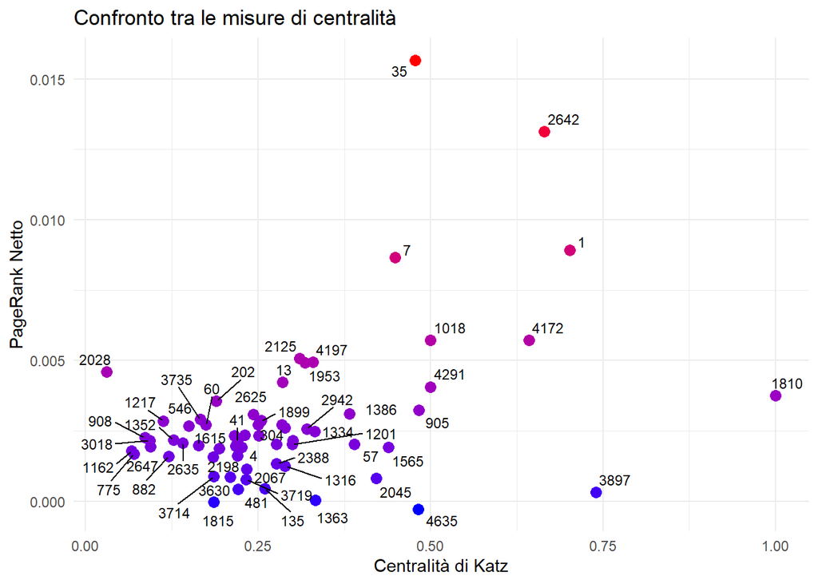

```r
# Sottografo archi positivi
#edges_pos <- E(g)[E(g)$weight > 0]
#g_pos <- subgraph.edges(g, edges_pos, delete.vertices = FALSE)

# Sottografo archi negativi
#edges_neg <- E(g)[E(g)$weight < 0]
#g_neg <- subgraph.edges(g, edges_neg, delete.vertices = FALSE)
E(g_neg)$weight <- abs(E(g_neg)$weight)

# Calcola PageRank separati
pr_positive <- page_rank(g_pos, weights = E(g_pos)$weight)$vector
pr_negative <- page_rank(g_neg, weights = E(g_neg)$weight)$vector

# Combina i risultati
nodes <- V(g)$name
pr_combined <- pr_positive - pr_negative

df_Centrality <- data.frame(
  ID = V(g)$name,
  Pagerank = pr_combined,
  Katz = V(g)$Katz / max(V(g)$Katz)
)

library(ggrepel)


top50_katz <- df_Centrality %>%
  arrange(desc(Katz)) %>%
  slice_head(n = 50) %>%
  pull(ID)

top50_pr <- df_Centrality %>%
  arrange(desc(Pagerank)) %>%
  slice_head(n = 50) %>%
  pull(ID)

top_nodes_all <- unique(c(top50_katz, top50_pr))

df_top <- df_Centrality %>%
  filter(ID %in% top_nodes_all)

ggplot(df_top, aes(x = Katz, y = Pagerank)) +
  geom_point(aes(color = Pagerank), size = 3) +
  geom_text_repel(aes(label = ID), size = 3, max.overlaps = 15) +
  scale_color_gradient(low = "blue", high = "red") +
  labs(
    title = "Confronto tra le misure di centralità",
    x = "Centralità di Katz",
    y = "PageRank Netto"
  ) +
  theme_minimal() +
  theme(legend.position = "none")
```

In questo contesto di studio come misure di centralità sono state scelte PageRank e la centralità di Katz. Queste due misure forniscono informazioni che possono essere definite complementari nel contesto dell’influenza dei nodi all’interno della rete di fiducia.

PageRank identifica gli utenti che ricevono fiducia da altri utenti già influenti. Non conta necessariamente il numero di connessioni che un nodo ha, in altre parole privilegia la qualità dei nodi che si fidano di te, non il numero di nodi che si fidano. Un nodo che ha un valore di PageRank alto significa che ha ricevuto l’endorsement dalla rete, può essere definito come un Broker della struttura.

Katz invece, considera tutti i possibili cammini di fiducia che raggiungono un nodo, privilegiando i cammini più brevi. Questo significa che misura la raggiungibilità globale di un utente attraverso catene di fiducia, analizzando il potenziale di un nodo di diffondere informazioni attraverso la rete.

Dopo il calcolo della centralità attraverso due differenti tipi di misure, lo studio evidenzia come i risultati siano differenti. Questa osservazione è normale, in quanto la centralità di Katz e PageRank si focalizzano su fatti differenti. PageRank punta alla qualità delle connessioni Katz sulla quantità.

Nella parte successiva risponderemo alla domanda numero due, attraverso il calcolo delle triadi verificheremo se la rete Bitocin OTC rispetta o no la teoria del bilanciamento.

## Teoria del bilanciamento

In questa ultima parte dedicata all’analisi locale studieremo una proprietà molto importante delle reti con segno: il bilanciamento strutturale.

In una rete come quella presa in analisi, il bilanciamento strutturale non è solo una mera proprietà statistica, ma rappresenta una caratteristica chiave per garantire la sicurezza e l’affidabilità del mercato.

Se i trader di cui un soggetto si fida, introducono un nuovo attore nel sistema è probabile che anch’esso si rivelerà un utente affidabile. Questo meccanismo di “fiducia transitiva” riduce il rischio finanziario.

Verifichiamo dunque se effettivamente la rete di Bitcoin OTC è effettivamente bilanciata.

```r
# La funzione triad_census_signed()  analizza tutte le possibili combinazioni di tre nodi, considerando sia i segni che la direzione.
risultato_triadi <- triad_census_signed(g)

df_triads <- data.frame(
  tipo = names(risultato_triadi),
  conteggio = as.numeric(risultato_triadi)
)

df_triads$stato <- ifelse(grepl("N", df_triads$tipo),
                          ifelse(stringr::str_count(df_triads$tipo, "N") %% 2 == 0, "Bilanciato", "Sbilanciato"),
                          "Bilanciato")

# Escludiamo le triadi vuote (003) o quasi vuote (102, 012) per il bilanciamento dei cicli
triadi_chiuse <- df_triads[grepl("030|120|210|300", df_triads$tipo), ]

totale_chiuse <- sum(triadi_chiuse$conteggio)
bilanciate <- sum(triadi_chiuse$conteggio[triadi_chiuse$stato == "Bilanciato"])

ratio_bilanciamento <- bilanciate / totale_chiuse
cat("Rapporto di Bilanciamento sulle triadi chiuse:", ratio_bilanciamento)
```

```
## Rapporto di Bilanciamento sulle triadi chiuse: 0.8497298
```

Nello studio del bilanciamento strutturale non è stato possibile utilizzare i metodi classici in quanto la rete è diretta (rappresentano transazioni gli archi), per cui è stata utilizzata la funzione triad_census_signed() che non presuppone che la rete sia non orientata.

Come si può notare l’indice ottenuto è pari all’ $85\%$, ciò indica che la rete possiede una buona coerenza interna. Questo indice evidenzia come la rete abbia sviluppato un sistema in cui la maggioranza delle relazioni segue una logica di mutua affidabilità.

Si può notare inoltre una percentuale non nulla di triadi sbilanciate esistono, questo può essere dovuto al processo di costruzione di fiducia ancora in atto tra gli utenti, oppure può essere dovuto ai così detti utenti controversi, di cui abbiamo discusso precedentemente.

Terminato questo primo capitolo riguardante l’analisi locale della rete, nel successivo discuteremo delle proprietà globali che caratterizzano Bitcoin OTC, in particolare studieremo se la rete rispetta le strutture dei modelli teorici, ed in particolare ne studieremo la resilienza agli attacchi, rispondendo così all’utlima domanda.

# Analisi globale

In questo ultimo capitolo verranno studiate le proprietà globali della rete Bitcoin OTC, in particolare analizzeremo se essa rispetta la topologia dei modelli teorici. Sfruttando la distribuzione del grado poi andremo a determinare se la rete è scale free. Come ultima analisi andremo a testare la resilienza della rete.

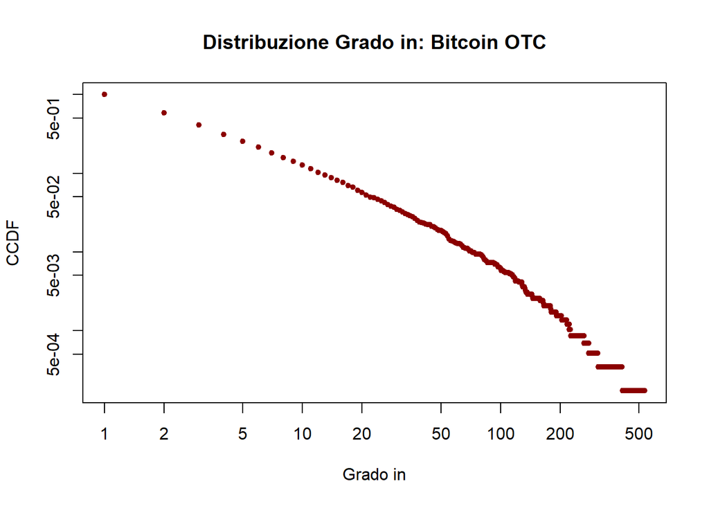

```r
# Cumulative distribution
ccdf = function(d) {
  n = length(d)
  max = max(d)
  p = rep(0, max)
  for (i in 1:length(p)) {
    p[i] = length(d[d >= i]) / n
  }
  return(p)
}


d_in    <- degree(g, mode="in");    d_in    <- d_in[d_in > 0]
d_out   <- degree(g, mode="out");   d_out   <- d_out[d_out > 0]
d_total <- degree(g, mode="total"); d_total <- d_total[d_total > 0]

# Calcolo CCDF
p_in <-  ccdf(d_in)
p_out <- ccdf(d_out)
p_total <- ccdf(d_total)

# Plot
plot(min(d_in):max(d_in), p_in[min(d_in):max(d_in)],
     log="xy", type = "p", pch=20, col="darkred",
     xlab="Grado in",
     ylab="CCDF",
     main="Distribuzione Grado in: Bitcoin OTC")
```

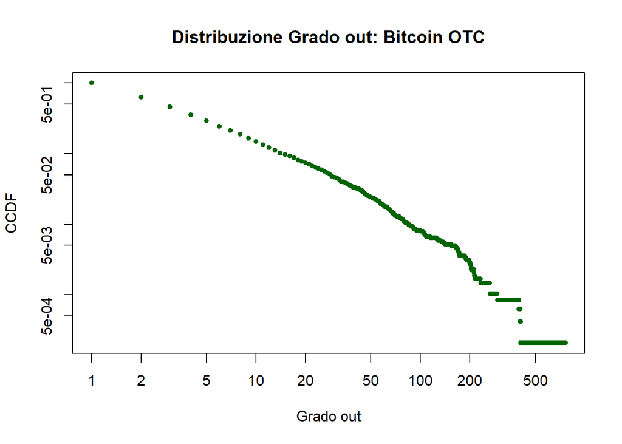

```r
plot(min(d_out):max(d_out), p_out[min(d_out):max(d_out)],
     log="xy", type = "p", pch=20, col="darkgreen",
     xlab="Grado out",
     ylab="CCDF",
     main="Distribuzione Grado out: Bitcoin OTC")
```

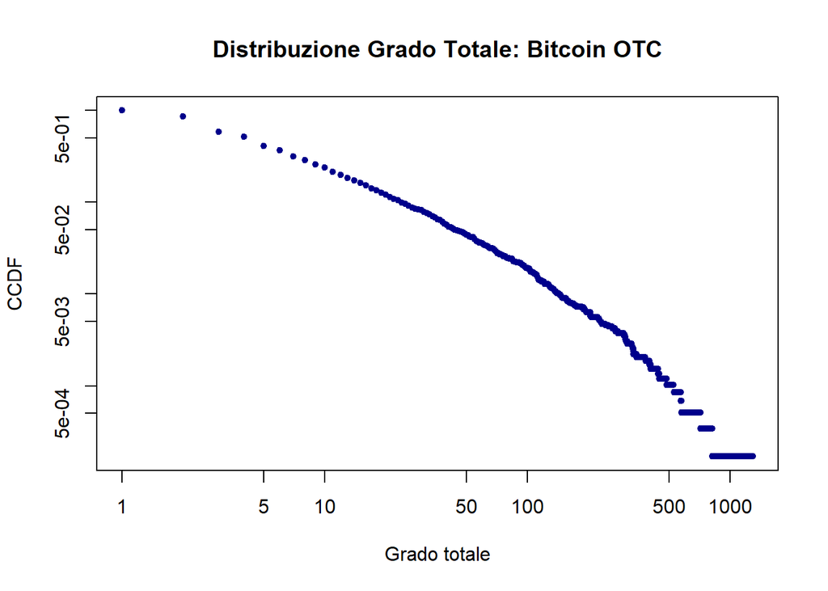

```r
plot(min(d_total):max(d_total), p_total[min(d_total):max(d_total)],
     log="xy", type = "p", pch=20, col="darkblue",
     xlab="Grado totale",
     ylab="CCDF",
     main="Distribuzione Grado Totale: Bitcoin OTC")
```

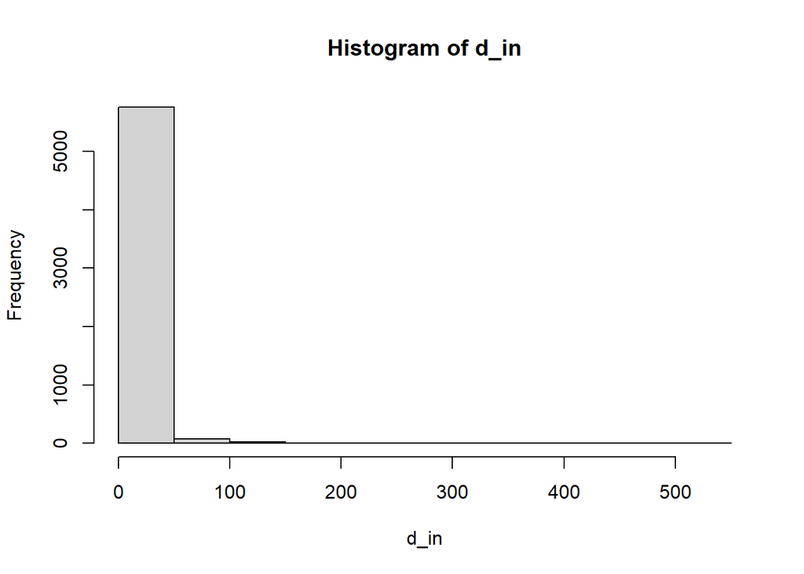

```r
skewness = function(x) mean( (x - mean(x))^3) / sd(x)^3
hist(d_in)
```

```r
skewness(d_in)
```

```
## [1] 12.37326
```

```r
fit <- fit_power_law(d_in)
cat("Esponente Alpha:", fit$alpha)
```

```
## Esponente Alpha: 2.2708
```

L’ analisi della distribuzione del grado, analizzata mediante:

1. Il grado in entrata
2. Il grado in uscita
3. Il grado totale

Mostra un risultato chiaro. Lo studio è stato fatto mediante la Complementary Cumulative Distribution Function (CCDF) su scala bi-logaritmica. L’esito è andamento lineare in tutti e tre i casi.

Questo conferma che la topologia della rete Bitcoin OTC rispecchia il modello teorico delle reti scale-free.

Come previsto dal modello di preferential attachment di Barabasi-Albert, i nuovi utenti tendono ad interagire con chi possiede già un’alta reputazione, creando super-hub che tengono unita la struttura.

Per confermare i risultati ottenuti, per la distribuzione del grado in entrata sono stati effettuati due test statistici. Il primo ha verificato la forte asimmetria, è stato utilizzato l’indice di skewness. Il quale ha otttenuto come risultato circa 12.37. Il secondo test ha calcolato l’esponente $\alpha$ della power law che è risultato pari a 2.27.

Il prossimo passo è analizzare la resilienza della rete, studiando se essa è capace di resistere sia ad attacchi esterni sia a malfunzionamenti. Il processo di analisi sarà attuato rimuovendo man mano, secondo diverse strategie i nodi della rete fino alla rimozione della metà degli elementi della rete.

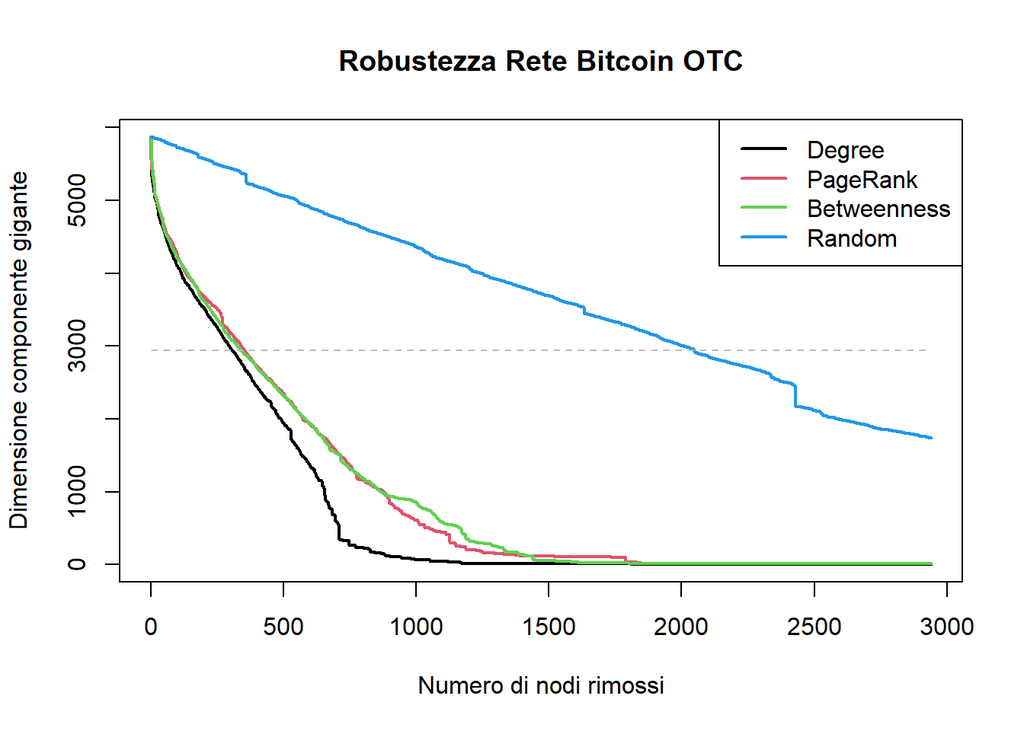

```r
# Funzione percolate
percolate = function(g, size, d) {

  giant = vector()

  # initial size of giant component
  c = components(g)
  giant[1] = max(c$csize)

  # find vital nodes
  names(d) = 1:length(d)
  d = sort(d, decreasing=TRUE)
  vital = as.integer(names(d[1:size]))

  # compute size of giant component after incremental removal
  for (i in 1:size) {
    c = components(delete_vertices(g, vital[1:i]))
    giant[i+1] = max(c$csize)
  }

  return(giant)
}

# Test resilienza sulla rete Bitcoin OTC
size = floor(vcount(g)/2)

# Random
rand = percolate(g, size, d = sample(V(g), size))

# Degree
deg = percolate(g, size, d = degree(g, mode="all"))

# PageRank con pesi
pr = percolate(g, size, d = page_rank(g, weights=abs(E(g)$weight))$vector)

# Betweenness con pesi
bet = percolate(g, size, d = betweenness(g, weights=1/abs(E(g)$weight)))

# Visualizzazione
plot(0:size, deg, type="l", col=1, lwd=2,
     xlab="Numero di nodi rimossi",
     ylab="Dimensione componente gigante",
     main="Robustezza Rete Bitcoin OTC",
     ylim=c(0, max(deg)))
lines(0:size, pr, col=2, lwd=2)
lines(0:size, bet, col=3, lwd=2)
lines(0:size, rand, col=4, lwd=2)
lines(0:size, rep(vcount(g)/2, size+1), lty=2, col="gray")

legend(x="topright",
       legend=c("Degree", "PageRank", "Betweenness", "Random"),
       lty=1, col=1:4, lwd=2)
```

Il grafico conferma i rislutati dell’analisi ottenuta dalla CCDF. Le rete Bitcoin OTC è una rete che segue il modello di preferential attachment.

Come il grafico evidenza la rete è resiliente riguardo i guasti, lo si può dedurre dal fatto che la strategia casuale è la peggiore delle quattro in elenco. Dall’altro canto Bitcoin OTC è molto sensibile agli attacchi esterni, questa caratteristica è dovuta alla presenza di super hub, infatti la rimozione per grado e PageRank sono risultate le strategie più efficaci.

# Conclusione

In conclusione l’analisi di questa trusted network ha ottenuto dei risultati affascinanti per quanto concerne le domande di ricerca.

Per quanto riguarda la prima domanda, l’analisi ha evidenziato una chiara gerarchia all’interno della rete rispetto alla fiducia. Essa è stata studiata mediante due misure di centralità: Katz e PageRank.

Per quanto riguarda la seconda domanda di ricerca, l’esito dell’analisi ha dimostrato che, grazie ad un coefficiente di bilanciamento pari a quasi l’85%, la rete è sostanzialmente bilanciata. Questo risultato dimostra che il sistema ha sviluppato una logica di mutua affidabilità, dove la fiducia transitiva funziona efficientemente. Il 15% di triadi sbilanciate dimostra che sono presenti utenti non affidabili o fraudolenti.

L’effetto può essere duplice, in primo luogo potrebbe significare che il processo di instaurazione della fiducia in certi determinati utenti è ancora in atto, dall’altro canto potrebbe significare che effettivamente all’interno della rete sono presenti utenti malevoli.

La terza ed ultima domanda di questa analisi riguarda la topologia e la resilienza della rete. Inizialmente tramite un’ analisi della distribuzione del grado tramite CCDF abbiamo confermato che la topologia della rete segue quella delle reti scale-free. Ciò è dovuto al fatto che la distribuzione mostra un andamento lineare in scala bi-logaritmica per ogni tipologia di grado, confermando che la rete segue il modello di reti di Barabasi-Albert.

Questa specifica topologia, come evidenzia lo studio della resilienza, ha un’ottima resistenza ai guasti casuali, in quanto sostanzialmente a meno che non vengano rimossi i super-hub la connettività non viene danneggiata. La rete però è pessima rispetto agli attacchi mirati come il grafico riassuntivo dimostra. Questo conferma ulteriormente il fatto che la topologia della rete segue i modelli preferential attachment.